# PCA of plant species

David Ju Nyambe

1/19/2021

## Introduction

Principle Component Analysis(P.C.A) is a dimension reduction technique that helps to reduce the amount of dimensions contained by a large dataset without losing much information.

- Helps to visualize data. It is not easy to visualize data that is in 3 dimensions or more.
- Reduces the chances of overfitting occurring
- Reducing the dimensions on a data helps reduce the time taken for any operation performed on the dataset therefore improving performance
- Datasets may contain information that is not of importance therefore PCA helps to pick out information that is of most importance.

```r
install.packages("remotes",repos = "http://cran.us.r-project.org")
```

```r
install.packages("ggplot2",repos = "http://cran.us.r-project.org")
remotes::install_github("vqv/ggbiplot", force = TRUE)
library(ggbiplot)
```

## Loading the iris dataset

A preview of the iris dataset is performed using str().

```
## 'data.frame':    150 obs. of  5 variables:
##  $ Sepal.Length: num  5.1 4.9 4.7 4.6 5 5.4 4.6 5 4.4 4.9 ...
##  $ Sepal.Width : num  3.5 3 3.2 3.1 3.6 3.9 3.4 3.4 2.9 3.1 ...
##  $ Petal.Length: num  1.4 1.4 1.3 1.5 1.4 1.7 1.4 1.5 1.4 1.5 ...
##  $ Petal.Width : num  0.2 0.2 0.2 0.2 0.2 0.4 0.3 0.2 0.2 0.1 ...
##  $ Species     : Factor w/ 3 levels "setosa","versicolor",..: 1 1 1 1 1 1 1 1 1 1 ...
```

## Creating the Principle Components

The Principle components are created using the prcomp(). It is not advisable to use categorical data in principle component analysis therefore the variable(Column) is not to be included.

```r
flowers_components<-prcomp(iris[,-5],scale. = TRUE)
```

```r
summary(flowers_components)
```

```
## Importance of components:
##                           PC1    PC2     PC3     PC4
## Standard deviation     1.7084 0.9560 0.38309 0.14393
## Proportion of Variance 0.7296 0.2285 0.03669 0.00518
## Cumulative Proportion  0.7296 0.9581 0.99482 1.00000
```

The proportion of variance explained by each component is calculated to help determine the amount of variability explained by each principle component

```r
std_dev <- flowers_components$sdev
variance_explained<-(100*flowers_components$sdev^2)/sum(flowers_components$sdev^2)
principle_variance <- std_dev^2
propotion_explained <-data.frame(PC= 1:length(variance_explained),variance_explained=variance_explained)
propotion_explained
```

```
##   PC variance_explained
## 1  1         72.9624454
## 2  2         22.8507618
## 3  3          3.6689219
## 4  4          0.5178709
```

Using proportion of the variance, a scree plot is created to determine how many principle components are to be used in order to get a good percentage of variability.

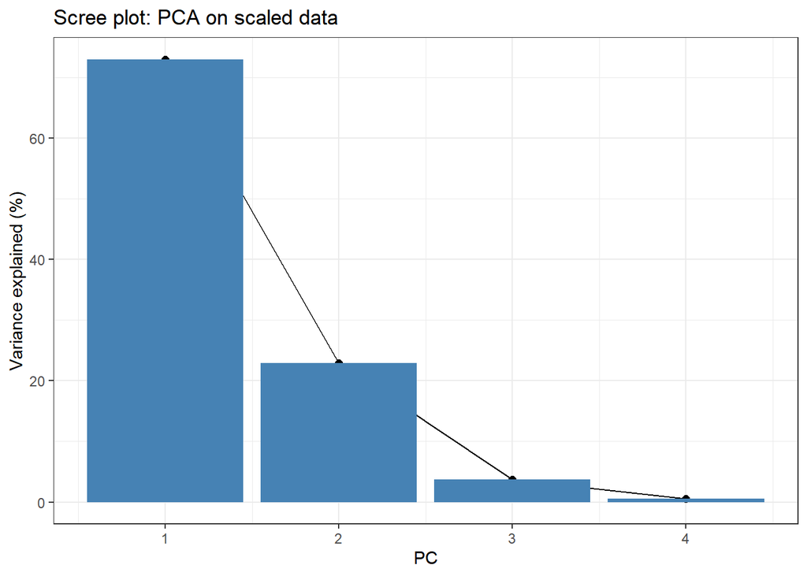

```r
 ggplot(data=propotion_explained,aes(x=PC,y=variance_explained))+
  geom_point(size=2)+
  geom_line()+theme_bw()+geom_col(fill="steelblue")+scale_x_continuous(breaks=1:nrow(propotion_explained))+
  labs(title="Scree plot: PCA on scaled data",y="Variance explained (%)",x="PC")
```

Using the rule of elbow its clear to see that two principle components would be needed to explain a good amount of variance..

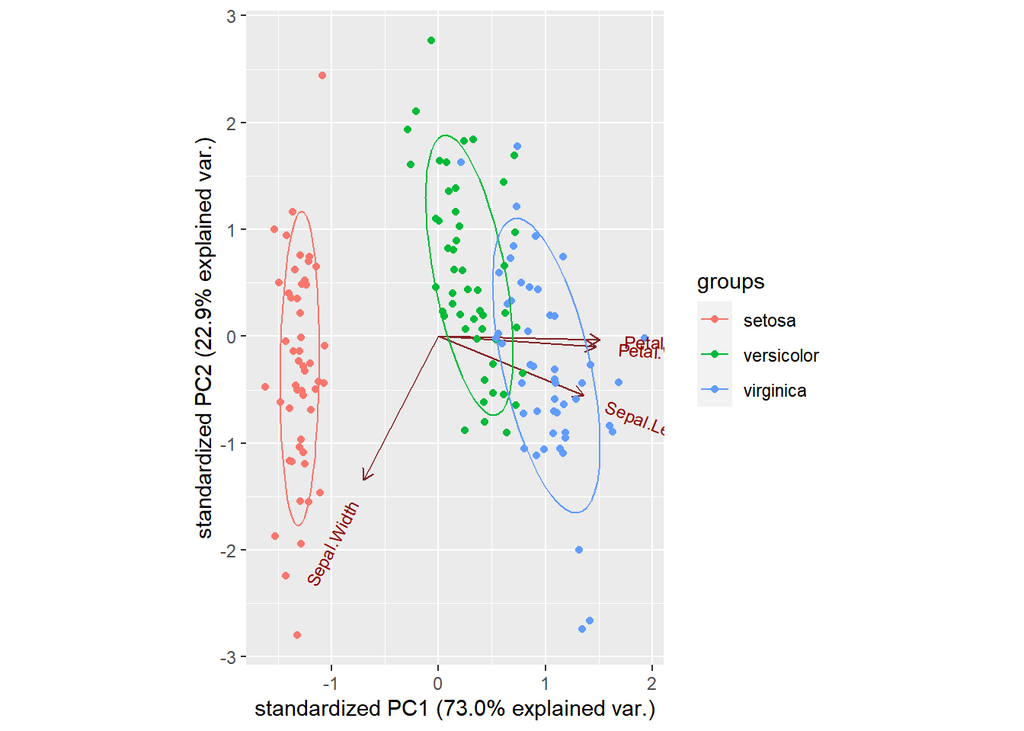

```r
ggbiplot(flowers_components,groups=iris[,5],ellipse=TRUE)
```